# Practical Machine Learning Course Project

Teo Lye Choon

Saturday, July 18, 2015

## Background

Using devices such as Jawbone Up, Nike FuelBand, and Fitbit it is now possible to collect a large amount of data about personal activity relatively inexpensively. These type of devices are part of the quantified self movement - a group of enthusiasts who take measurements about themselves regularly to improve their health, to find patterns in their behavior, or because they are tech geeks. One thing that people regularly do is quantify how much of a particular activity they do, but they rarely quantify how well they do it. In this project, the goal will be to use data from accelerometers on the belt, forearm, arm, and dumbell of 6 participants. They were asked to perform barbell lifts correctly and incorrectly in 5 different ways.

## Loading the necessary libraries

```r
library(ggplot2)
library(lattice)
library(caret)
library(rpart)
library(rpart.plot)
library(randomForest)
library(corrplot)
```

## Downloading the Data

```r
trainUrl <-"http://d396qusza40orc.cloudfront.net/predmachlearn/pml-training.csv"
testUrl <- "http://d396qusza40orc.cloudfront.net/predmachlearn/pml-testing.csv"
trainFile <- "pml-training.csv"
testFile  <- "pml-testing.csv"
if (!file.exists(trainFile)) {
  download.file(trainUrl, trainFile)
}
if (!file.exists(testFile)) {
  download.file(testUrl, testFile)
}
```

## Reading the Data

The two csv files will be read with all blank(‘’),’#DIV/0’ and ‘NA’ values converted to ‘NA’.

```r
trainRaw <- read.csv("pml-training.csv", na.strings=c("NA","#DIV/0!", ""))
testRaw <- read.csv("pml-testing.csv", na.strings=c("NA","#DIV/0!", ""))
```

## Exploring the Data

```r
dim(trainRaw)
```

```
## [1] 19622   160
```

```r
dim(testRaw)
```

```
## [1]  20 160
```

## Cleaning the Data

- Remove variables with more than 80% missing values since these variables will not contribute much to the prediction.

```r
# Training Data
trainNA <- sapply(colnames(trainRaw),
              function(x)
                if (sum(is.na(trainRaw[ ,x])) > 0.8 * nrow(trainRaw))
                    {return(T)}
                else {return(F)}
              )
trainNoNA <- trainRaw[ ,!trainNA]
dim(trainNoNA)
```

```
## [1] 19622    60
```

```r
# Test Data
testNA <- sapply(colnames(testRaw),
              function(x)
                if (sum(is.na(testRaw[ ,x])) > 0.8 * nrow(testRaw))
                    {return(T)}
                else {return(F)}
              )
testNoNA <- testRaw[ ,!testNA]
dim(testNoNA)
```

```
## [1] 20 60
```

Some columns that do not contribute much to the accelerometer measurements are also removed.

```r
# Train Data
classe <- trainNoNA$classe
remove = c('X', 'user_name', 'raw_timestamp_part_1', 'raw_timestamp_part_2',
           'cvtd_timestamp', 'new_window', 'num_window')
trainRemove <- trainNoNA[, -which(names(trainNoNA) %in% remove)]
trainClean <- trainRemove[ ,sapply(trainRemove, is.numeric)]
trainClean$classe <- classe
dim(trainClean)
```

```
## [1] 19622    53
```

```r
# Test Data
testRemove <- testNoNA[, -which(names(trainNoNA) %in% remove)]
testClean <- testRemove[ ,sapply(testRemove, is.numeric)]
dim(testClean)
```

```
## [1] 20 53
```

## Slicing the data

The clean training data will be splited into a training data (70%) and a validation data (30%). The validation data will be used for cross validation.

```r
set.seed(180715)
inTrain <- createDataPartition(y=trainClean$classe, p=0.70, list=FALSE)
trainData <- trainClean[inTrain, ]
ValidationData <- trainClean[-inTrain, ]
```

## Data Modeling

A predictive model with Random Forest algorithm will be used as it automatically selects the important variables and is robust enough to correlate covariates & outliers in general. The 5-fold cross validation will be used when applying the algorithm.

```r
controlRf <- trainControl(method="cv", 5)
modelRf <- train(classe ~ ., data=trainData, method="rf", trControl=controlRf,
                 ntree=25)
modelRf
```

```
## Random Forest
##
## 13737 samples
##    52 predictor
##     5 classes: 'A', 'B', 'C', 'D', 'E'
##
## No pre-processing
## Resampling: Cross-Validated (5 fold)
##
## Summary of sample sizes: 10990, 10990, 10988, 10990, 10990
##
## Resampling results across tuning parameters:
##
##   mtry  Accuracy   Kappa      Accuracy SD  Kappa SD
##    2    0.9868236  0.9833301  0.003581019  0.004531525
##   27    0.9898811  0.9871994  0.001792037  0.002268591
##   52    0.9826750  0.9780843  0.002362166  0.002985666
##
## Accuracy was used to select the optimal model using  the largest value.
## The final value used for the model was mtry = 27.
```

The performance of the model will be assessed using the validation data.

```r
predictRf <- predict(modelRf, ValidationData)
confusionMatrix(ValidationData$classe, predictRf)
```

```
## Confusion Matrix and Statistics
##
##           Reference
## Prediction    A    B    C    D    E
##          A 1672    2    0    0    0
##          B    5 1133    1    0    0
##          C    0    2 1020    4    0
##          D    0    1   10  953    0
##          E    0    1    2    4 1075
##
## Overall Statistics
##
##                Accuracy : 0.9946
##                  95% CI : (0.9923, 0.9963)
##     No Information Rate : 0.285
##     P-Value [Acc > NIR] : < 2.2e-16
##
##                   Kappa : 0.9931
##  Mcnemar's Test P-Value : NA
##
## Statistics by Class:
##
##                      Class: A Class: B Class: C Class: D Class: E
## Sensitivity            0.9970   0.9947   0.9874   0.9917   1.0000
## Specificity            0.9995   0.9987   0.9988   0.9978   0.9985
## Pos Pred Value         0.9988   0.9947   0.9942   0.9886   0.9935
## Neg Pred Value         0.9988   0.9987   0.9973   0.9984   1.0000
## Prevalence             0.2850   0.1935   0.1755   0.1633   0.1827
## Detection Rate         0.2841   0.1925   0.1733   0.1619   0.1827
## Detection Prevalence   0.2845   0.1935   0.1743   0.1638   0.1839
## Balanced Accuracy      0.9983   0.9967   0.9931   0.9947   0.9993
```

```r
accuracy <- postResample(predictRf, ValidationData$classe)
accuracy
```

```
##  Accuracy     Kappa
## 0.9945624 0.9931218
```

```r
outSampleError <- 1 - as.numeric(confusionMatrix(ValidationData$classe,
                                                 predictRf)$overall[1])
outSampleError
```

```
## [1] 0.005437553
```

## Predicting for Test Data

The model will be used on the original testing data with the ’problem_id` removed.

```r
result <- predict(modelRf, testClean[, -length(names(testClean))])
result
```

```
##  [1] B A B A A E D B A A B C B A E E A B B B
## Levels: A B C D E
```

## Conclusion

The random forest model has a good accuracy but caution must be taken from Overfitting.

## Appendix 1 : Correlation Matrix Visualization

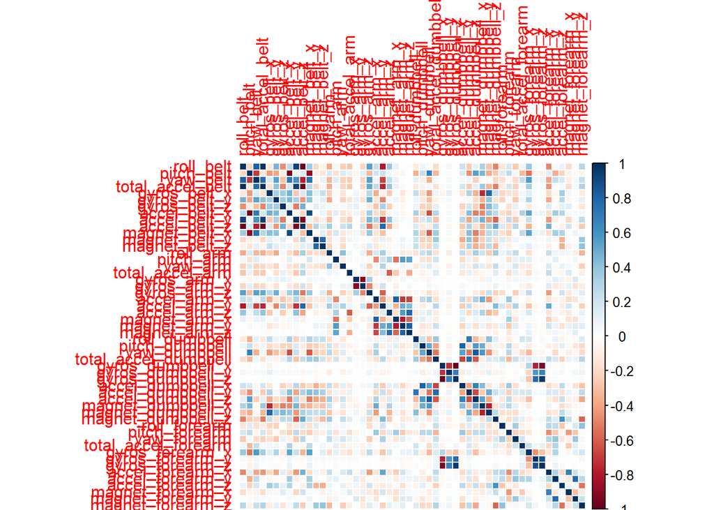

```r
corrPlot <- cor(trainData[ ,-length(names(trainData))])
corrplot(corrPlot, method="color")
```

## Appendix 2 : Decision Tree Visualization

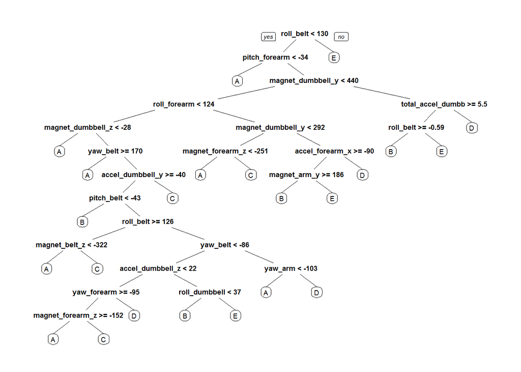

```r
treeModel <- rpart(classe ~ . ,data=trainData, method="class")
prp(treeModel)
```

## Appendix 3 : Assignment Submission

```r
pml_write_files = function(x){
    n = length(x)
    for(i in 1:n){
        filename = paste0("problem_id_",i,".txt")
        write.table(x[i],file=filename,quote=FALSE,row.names=FALSE,
                    col.names=FALSE)
    }
}

pml_write_files(result)
```

## Appendix 4 : References

- The information used for this project is referenced from the Human Activity Recognition publication.
- More information is available from the website http://groupware.les.inf.puc-rio.br/har especially on the section for the Weight Lifting Exercise Dataset.